# Profit Maximisation and Competitive Markets

September 29, 2015

# 1. Taxes and Subsidies

The demand curve is given by

$Q_{D} = 18 - 2P$

The supply curve is given by

$Q_{S} = -2 + 8P$

```r
#load some libraries
library(dplyr)
library(tidyr)
library(ggplot2)
library(knitr)

#define the supply and demand functions
supply <- function(p) {
  return( -2 + 8*p )
}

demand <- function(p) {
  return(18-2*p)
}

supply_sub <- function(p,t) {
  return( -2 + 8*(p+t))
}

demand_sub <- function(p,t) {
  return(18-2*(p-t))
}

#create a dataframe with price going from 0 to 10, and calculate the other variables for each q
market1 <- data.frame(
  price=c(0:30)*0.1
  ) %>%
  mutate(
    supply = supply(price),
    demand = demand(price),
    supply_2 = supply_sub(price,1),
    demand_2 = demand_sub(price,1)
  )

market1Narrow <- market1 %>%
gather(variable,quantity,supply:demand_2)
```

Here’s what the market looks like in equilibrium

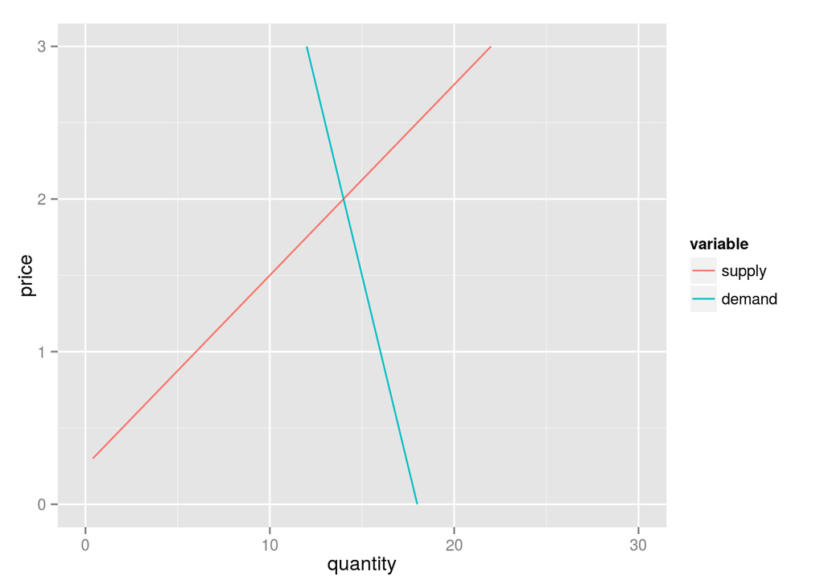

```r
#plot value against quantity, grouping by variable
ggplot(filter(
  market1Narrow,variable!="demand_2" &variable!="supply_2"
  ),aes(quantity,price,colour=variable)) + geom_line() +xlim(c(0,30))
```

Here’s what the data looks like

```r
kable(market1)
```

| price | supply | demand | supply_2 | demand_2 |
| --- | --- | --- | --- | --- |
| 0.0 | -2.0 | 18.0 | 6.0 | 20.0 |
| 0.1 | -1.2 | 17.8 | 6.8 | 19.8 |
| 0.2 | -0.4 | 17.6 | 7.6 | 19.6 |
| 0.3 | 0.4 | 17.4 | 8.4 | 19.4 |
| 0.4 | 1.2 | 17.2 | 9.2 | 19.2 |
| 0.5 | 2.0 | 17.0 | 10.0 | 19.0 |
| 0.6 | 2.8 | 16.8 | 10.8 | 18.8 |
| 0.7 | 3.6 | 16.6 | 11.6 | 18.6 |
| 0.8 | 4.4 | 16.4 | 12.4 | 18.4 |
| 0.9 | 5.2 | 16.2 | 13.2 | 18.2 |
| 1.0 | 6.0 | 16.0 | 14.0 | 18.0 |
| 1.1 | 6.8 | 15.8 | 14.8 | 17.8 |
| 1.2 | 7.6 | 15.6 | 15.6 | 17.6 |
| 1.3 | 8.4 | 15.4 | 16.4 | 17.4 |
| 1.4 | 9.2 | 15.2 | 17.2 | 17.2 |
| 1.5 | 10.0 | 15.0 | 18.0 | 17.0 |
| 1.6 | 10.8 | 14.8 | 18.8 | 16.8 |
| 1.7 | 11.6 | 14.6 | 19.6 | 16.6 |
| 1.8 | 12.4 | 14.4 | 20.4 | 16.4 |
| 1.9 | 13.2 | 14.2 | 21.2 | 16.2 |
| 2.0 | 14.0 | 14.0 | 22.0 | 16.0 |
| 2.1 | 14.8 | 13.8 | 22.8 | 15.8 |
| 2.2 | 15.6 | 13.6 | 23.6 | 15.6 |
| 2.3 | 16.4 | 13.4 | 24.4 | 15.4 |
| 2.4 | 17.2 | 13.2 | 25.2 | 15.2 |
| 2.5 | 18.0 | 13.0 | 26.0 | 15.0 |
| 2.6 | 18.8 | 12.8 | 26.8 | 14.8 |
| 2.7 | 19.6 | 12.6 | 27.6 | 14.6 |
| 2.8 | 20.4 | 12.4 | 28.4 | 14.4 |
| 2.9 | 21.2 | 12.2 | 29.2 | 14.2 |
| 3.0 | 22.0 | 12.0 | 30.0 | 14.0 |

Here’s a graphical representation of what happens if we give the subsidy to the supplier

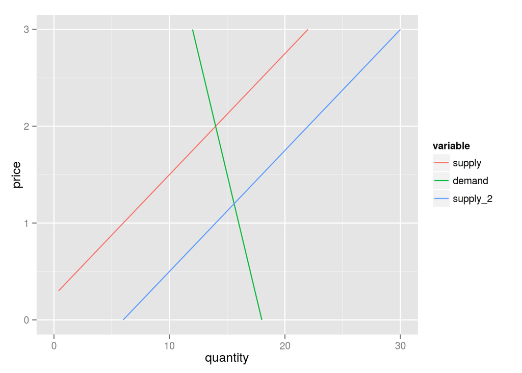

```r
#plot value against quantity, grouping by variable
ggplot(filter(
  market1Narrow,variable!="demand_2"
  ),aes(quantity,price,colour=variable)) + geom_line() +xlim(c(0,30))
```

Here’s a graphical representation of what happens if we give the subsidy to the consumer

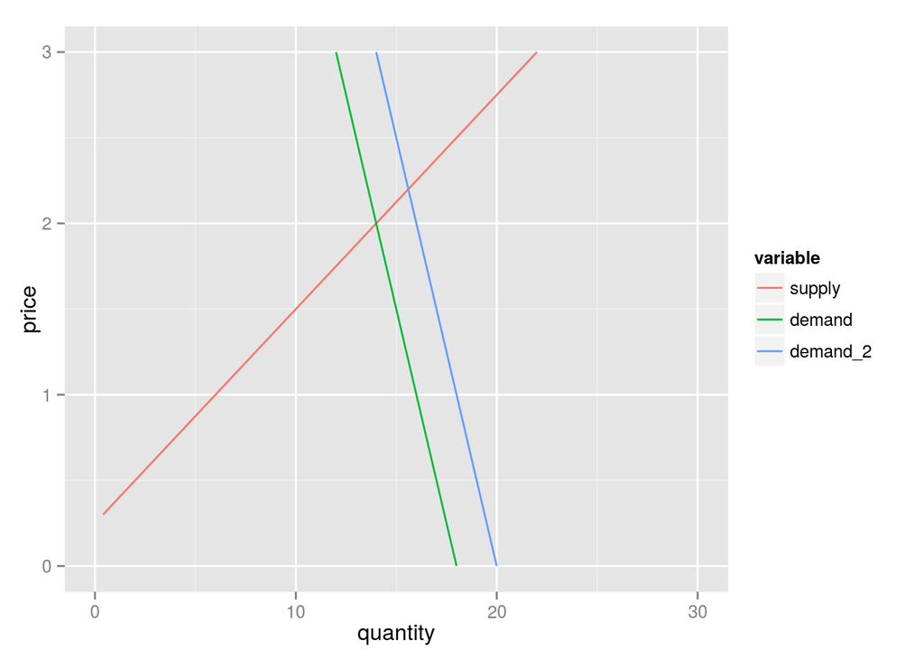

```r
ggplot(filter(
  market1Narrow,variable!="supply_2"
  ),aes(quantity,price,colour=variable)) + geom_line() +xlim(c(0,30))
```

# 2. Profit Maximisation

Suppose that a firm’s marginal cost is given by

$MC(Q) = 3 + 2Q$

```r
#define the marginal cost function
marginal_cost <- function(q) {
  return(3 + 2*q )
}

#create a market table for the firm
market2 <- data.frame(
  quantity=c(0:10)
  ) %>%
  mutate(
    price = 9,
    marginal_cost = marginal_cost(quantity)
  )

market2Narrow <- market2 %>%
gather(variable,value,price:marginal_cost)
```

Here’s what the data looks like

```r
kable(market2)
```

| quantity | price | marginal_cost |
| --- | --- | --- |
| 0 | 9 | 3 |
| 1 | 9 | 5 |
| 2 | 9 | 7 |
| 3 | 9 | 9 |
| 4 | 9 | 11 |
| 5 | 9 | 13 |
| 6 | 9 | 15 |
| 7 | 9 | 17 |
| 8 | 9 | 19 |
| 9 | 9 | 21 |
| 10 | 9 | 23 |

Here’s a graphical representation of marginal costs agains price

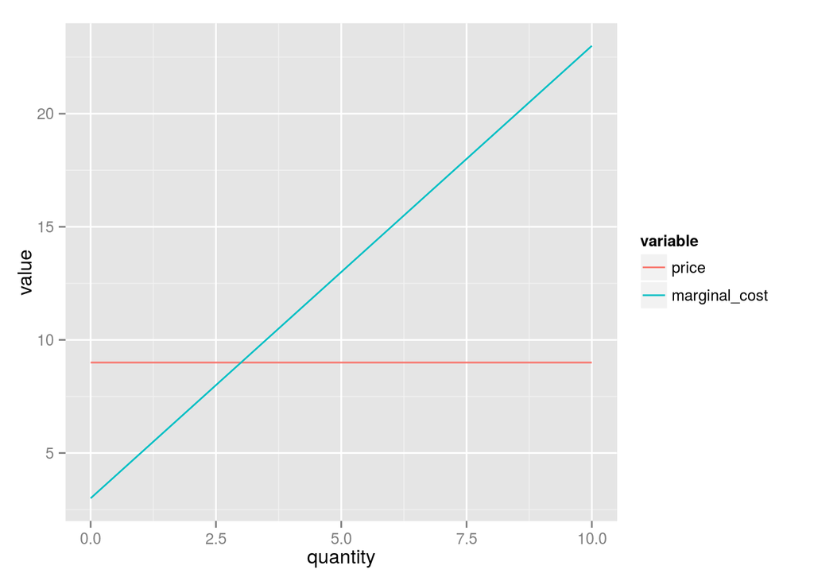

```r
ggplot(market2Narrow,aes(quantity,value,colour=variable)) + geom_line()
```

# 3. Market Power

Suppose that price is given by

$P=90-2Q$

Total cost is given by

$Cost=100+2Q^2$

Total revenue is given by

$Revenue=P*Q=90Q-2Q^2$

Marginal cost and marginal revenue are calculated by

$Value_{q+1}-Value_q,$

that is, the difference between the value at the current quantity and the value for an additional unit of quantity.

Profit is given by

$Revenue-Cost$

```r
#define the price and cost functions
price <- function(q) {
  return( 90 - 2*q )
}

cost <- function(q) {
  return(100+2*q^2)
}

#create a dataframe with quantity going from 0 to 20, and calculate the other variables for each q
market3 <- data.frame(
  quantity=c(0:20)
  ) %>%
  mutate(
    price = price(quantity),
    cost = cost(quantity),
    mar_cost = lead(cost)-cost,
    total_revenue_monopoly = price*quantity,
    marginal_revenue = lead(total_revenue_monopoly)-total_revenue_monopoly,
    profit_monopoly = total_revenue_monopoly - cost,
    average_costs = cost / quantity
    #simple_marginal_revenue = total_revenue-lag(total_revenue)
  )
```

```r
kable(market3)
```

| quantity | price | cost | mar_cost | total_revenue_monopoly | marginal_revenue | profit_monopoly | average_costs |
| --- | --- | --- | --- | --- | --- | --- | --- |
| 0 | 90 | 100 | 2 | 0 | 88 | -100 | Inf |
| 1 | 88 | 102 | 6 | 88 | 84 | -14 | 102.00000 |
| 2 | 86 | 108 | 10 | 172 | 80 | 64 | 54.00000 |
| 3 | 84 | 118 | 14 | 252 | 76 | 134 | 39.33333 |
| 4 | 82 | 132 | 18 | 328 | 72 | 196 | 33.00000 |
| 5 | 80 | 150 | 22 | 400 | 68 | 250 | 30.00000 |
| 6 | 78 | 172 | 26 | 468 | 64 | 296 | 28.66667 |
| 7 | 76 | 198 | 30 | 532 | 60 | 334 | 28.28571 |
| 8 | 74 | 228 | 34 | 592 | 56 | 364 | 28.50000 |
| 9 | 72 | 262 | 38 | 648 | 52 | 386 | 29.11111 |
| 10 | 70 | 300 | 42 | 700 | 48 | 400 | 30.00000 |
| 11 | 68 | 342 | 46 | 748 | 44 | 406 | 31.09091 |
| 12 | 66 | 388 | 50 | 792 | 40 | 404 | 32.33333 |
| 13 | 64 | 438 | 54 | 832 | 36 | 394 | 33.69231 |
| 14 | 62 | 492 | 58 | 868 | 32 | 376 | 35.14286 |
| 15 | 60 | 550 | 62 | 900 | 28 | 350 | 36.66667 |
| 16 | 58 | 612 | 66 | 928 | 24 | 316 | 38.25000 |
| 17 | 56 | 678 | 70 | 952 | 20 | 274 | 39.88235 |
| 18 | 54 | 748 | 74 | 972 | 16 | 224 | 41.55556 |
| 19 | 52 | 822 | 78 | 988 | 12 | 166 | 43.26316 |
| 20 | 50 | 900 | NA | 1000 | NA | 100 | 45.00000 |

Here is what we happen when we plot them

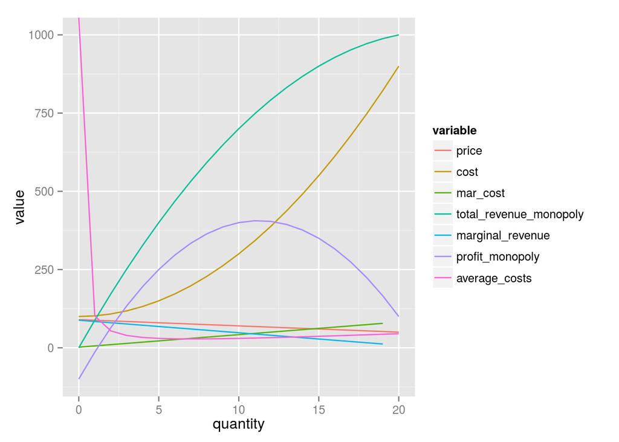

```r
#gather the variables into two columns, variable and value
market3Narrow <- market3 %>%
gather(variable,value,price:average_costs)

#plot value against quantity, grouping by variable
ggplot(market3Narrow,aes(quantity,value,colour=variable)) + geom_line()
```

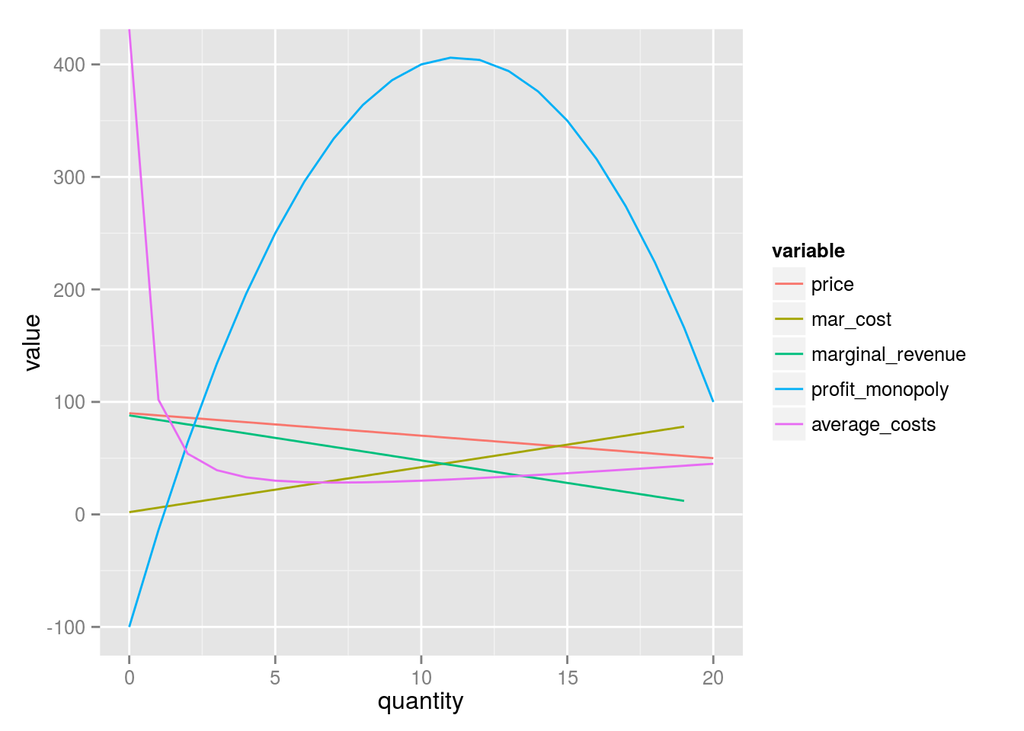

```r
#remove total revenue and cost for better scale
ggplot(filter(
  market3Narrow,variable != "total_revenue_monopoly" & variable != "cost"
  ), aes(quantity,value,colour=variable)) + geom_line()
```

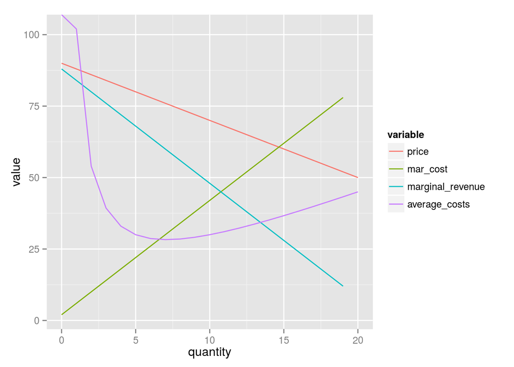

```r
ggplot(filter(
  market3Narrow,variable != "total_revenue_monopoly" & variable != "cost" & variable != "profit_monopoly"
  ), aes(quantity,value,colour=variable)) + geom_line()
```